# R Tutorial for CA 3: Working with Named Distributions and Sampling

Authors: Leonore Findsen, Timothy Reese, Halin Shin, Jeremy Troisi STAT 350

# The general form: task prefix + name of the distribution

In R language, functions involving known distributions are generally named with a single-letter prefix representing the desired task, followed by the name of the distribution.

For example, try running:

```r
rnorm(10, mean=2, sd=0.1)
```

```
##  [1] 2.057324 2.107380 2.051944 1.972280 1.906241 1.974466 2.053314 2.181800
##  [9] 1.944498 1.939041
```

Above, `r` represents the task of *random sampling*, and `norm` represents *normal distribution*. `rnorm(10, mean=2, sd=0.1)` creates a length-$n$ vector filled with random observations from normal distribution with $\mu=2$ and $\sigma=0.1$. **When `mean` and `sd` are not specified, `rnorm` assumes standard normal distribution.**

## Other prefixes

Continue to suppose that we are working with a random variable $X$ following normal distribution with $\mu=2$ and $\sigma=0.1$.

### “d” for density (pdf)

`d+name of distribution` gives the evaluation of the pmf or the pdf at the given input value. For example,

```r
dnorm(2, mean=2, sd=0.1)
```

```
## [1] 3.989423
```

is the evaluation of the pdf $X$ at $x=2$.

### “p” for cumulative probability (cdf)

`p+name of distribution` computes the cumulative probability $P(X \leq \text{input})$.

```r
pnorm(2, mean=2, sd=0.1)
```

```
## [1] 0.5
```

Remember that the `p+name of distribution` functions are always defined using the “less than or equal to” sign, $\leq$. The knowledge of this fact may influence your results involving discrete distributions.

### “q” for quantile

`q+name of distribution` computes the quantile $x$ satisfying $\text{input} = P(X \leq x)$.

```r
qnorm(0.5, mean=2, sd=0.1)
```

```
## [1] 2
```

### “r” for random sample

Finally, the random sampling task is restated for completeness.

```r
rnorm(10, mean=2, sd=0.1)
```

```
##  [1] 1.983257 1.853933 1.938687 2.023015 1.957880 2.058344 1.837056 1.841285
##  [9] 2.008765 1.989763
```

## Other distributions

- Beta: `beta`
- Binomial: `binom`
- Cauchy: `cauchy`
- Chi-square: `chisq`
- Exponential: `exp`
- F: `f`
- Gamma: `gamma`
- LogNormal: `lnorm`
- normal: `norm`
- Poisson: `pois`
- Student’s t: `t`
- Uniform: `unif`
- Weibull: `weibull`

```r
dpois(2, lambda=1) #Poisson
```

```
## [1] 0.1839397
```

```r
qexp(0.2, rate=1) #exponential; rate = lambda
```

```
## [1] 0.2231436
```

# Working with a random sample

All `r+name of distribution` functions give their output as a vector, which means that we can apply the vector functions learned in CA 1 and CA 2.

## Using a seed

In CA 3, all parts related to one distribution must be completed using the same set of observations. This can be tricky because every time you click “run” in the default setting, a new set of numbers is generated. For reproducibility, R allows you to fix the **seed** of random generation. When a fixed seed is used, the same set of random numbers will be generated over different runs.

### Without seed specification

```r
rnorm(5)
```

```
## [1] -0.04701438  0.44454431  0.66766416  1.20222598 -0.69045818
```

```r
rnorm(5)
```

```
## [1]  0.1528669 -1.2344644 -0.9206679 -1.8512973 -0.8135921
```

```r
rnorm(5)
```

```
## [1] -0.3770250 -0.9271884  0.8429667  1.2228096  1.0682855
```

### When a seed is fixed

```r
set.seed(1234)
rnorm(5);
```

```
## [1] -1.2070657  0.2774292  1.0844412 -2.3456977  0.4291247
```

```r
set.seed(1234)
rnorm(5);
```

```
## [1] -1.2070657  0.2774292  1.0844412 -2.3456977  0.4291247
```

```r
set.seed(1234)
rnorm(5)
```

```
## [1] -1.2070657  0.2774292  1.0844412 -2.3456977  0.4291247
```

To use this feature, it suffices to write `set.seed(your seed number)` at the beginning of your R script.

# Completing the assignment

Suppose we would like to work with a sample of size $n=20$ drawn from a normal distribution with $\mu=572$ and $\sigma=51$.

## Generate the data

```r
set.seed(12345)
n <- 20
RandomData <- rnorm(n, mean=572, sd=51)
print(RandomData)
```

```
##  [1] 601.8620 608.1828 566.4255 548.8716 602.9003 479.2842 604.1350 557.9146
##  [9] 557.5079 525.1146 566.0714 664.6829 590.9020 598.5310 533.7229 613.6619
## [17] 526.7958 555.0895 629.1563 587.2349
```

## Compute the numerical summary

```r
xbar <- mean(RandomData)
xbar
```

```
## [1] 575.9024
```

```r
s <- sd(RandomData)
s
```

```
## [1] 42.53071
```

## Graphically assessing normality

Before beginning this section, make sure that `ggplot2` is installed on your RStudio. If not, revisit CA 2a tutorial. If `ggplot2` is already installed, then load it into the current session by first running

```r
library(ggplot2)
```

A `ggplot` function only accepts data in the form of `data.frame` (a way of saying “table” in the language of R). Therefore, we must first re-format the `RandomData` vector into a`data.frame` of single column by running

```r
RandomDataDF <- data.frame(RandomData=RandomData)
RandomDataDF
```

| RandomData |
| --- |
| 601.8620 |
| 608.1828 |
| 566.4255 |
| 548.8716 |
| 602.9003 |
| 479.2842 |
| 604.1350 |
| 557.9146 |
| 557.5079 |
| 525.1146 |

[output cut: 10 more lines]

### Assessing normality through a histogram

Define the number of bins.

```r
number_bins <- max(round(sqrt(n))+2,5)
```

Draw the histogram. Always include the red and blue curves in a histogram.

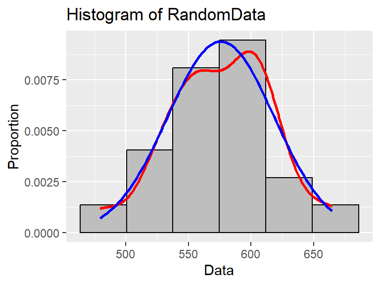

```r
ggplot(RandomDataDF, aes(x=RandomData)) +
  geom_histogram(aes(y= after_stat(density)), bins = number_bins,
                 fill="grey", col="black") +
  geom_density(col="red", lwd=1) +
  stat_function(fun=dnorm, args=list(mean=xbar, sd=s), col="blue", lwd=1) +
  xlab("Data") +
  ylab("Proportion") +
  ggtitle("Histogram of RandomData")
```

There are two complimentary ways to determine if a histogram looks normal.

1. Assess whether the blue normal curve is ‘close’ to the red smoothed curve.
2. Determine whether the histogram itself forms an approximately normal shape based on the symmetry, modality and tails.

It is recommended to always use both methods. In this case, the two curves are similar, and the histogram looks unimodal and approximately symmetric. Therefore, we conclude that this histogram resembles a normal distribution.

### Make a normal probability plot

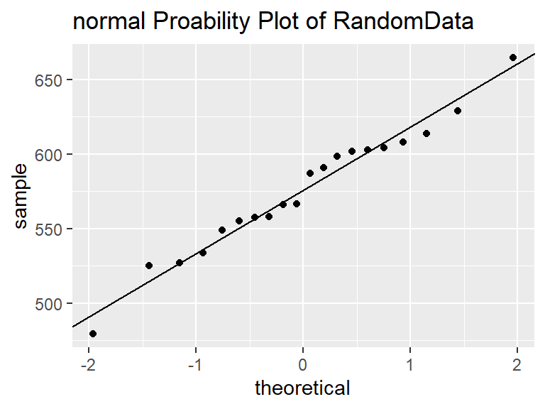

```r
ggplot(RandomDataDF, aes(sample=RandomData)) +
  stat_qq() +
  geom_abline(slope=s, intercept=xbar) +
  ggtitle("normal Proability Plot of RandomData")
```

Since the data points follow the straight line reasonably well, the randomly generated data does not appear to deviate substantially from a normal distribution.

## Other distributions

The assignment will ask you to repeat the example above using four other distributions. For all distributions, including normal, you must use the parameter values provided by the assignment, not this tutorial. Use the help function in R to determine what parameters need to be set in R and how to sample from the specified distributions. For example the LogNormal distribution.

```r
help(rlnorm)
```

| Lognormal | R Documentation |
| --- | --- |

## The Log Normal Distribution

### Description

Density, distribution function, quantile function and random generation for the log normal distribution whose logarithm has mean equal to `meanlog` and standard deviation equal to `sdlog`.

### Usage

```r
dlnorm(x, meanlog = 0, sdlog = 1, log = FALSE)
plnorm(q, meanlog = 0, sdlog = 1, lower.tail = TRUE, log.p = FALSE)
qlnorm(p, meanlog = 0, sdlog = 1, lower.tail = TRUE, log.p = FALSE)
rlnorm(n, meanlog = 0, sdlog = 1)
```

### Arguments

| `x`, `q` | vector of quantiles. |
| --- | --- |
| `p` | vector of probabilities. |
| `n` | number of observations. If `length(n) > 1`, the length is taken to be the number required. |
| `meanlog`, `sdlog` | mean and standard deviation of the distribution on the log scale with default values of `0` and `1` respectively. |
| `log`, `log.p` | logical; if TRUE, probabilities p are given as log(p). |
| `lower.tail` | logical; if TRUE (default), probabilities are `P[X \le x]`, otherwise, `P[X > x]`. |

### Details

where `\mu` and `\sigma` are the mean and standard deviation of the logarithm. The mean is `E(X) = exp(\mu + 1/2 \sigma^2)`, the median is `med(X) = exp(\mu)`, and the variance `Var(X) = exp(2\mu + \sigma^2)(exp(\sigma^2) - 1)` and hence the coefficient of variation is `\sqrt{exp(\sigma^2) - 1}` which is approximately `\sigma` when that is small (e.g., `\sigma < 1/2`).

### Value

`dlnorm` gives the density, `plnorm` gives the distribution function, `qlnorm` gives the quantile function, and `rlnorm` generates random deviates.

The length of the result is determined by `n` for `rlnorm`, and is the maximum of the lengths of the numerical arguments for the other functions.

The numerical arguments other than `n` are recycled to the length of the result. Only the first elements of the logical arguments are used.

### Note

The cumulative hazard `H(t) = - \log(1 - F(t))` is `-plnorm(t, r, lower = FALSE, log = TRUE)`.

### Source

`dlnorm` is calculated from the definition (in ‘Details’). `[pqr]lnorm` are based on the relationship to the normal.

Consequently, they model a single point mass at `exp(meanlog)` for the boundary case `sdlog = 0`.

### References

Becker, R. A., Chambers, J. M. and Wilks, A. R. (1988) *The New S Language*. Wadsworth & Brooks/Cole.

Johnson, N. L., Kotz, S. and Balakrishnan, N. (1995) *Continuous Univariate Distributions*, volume 1, chapter 14. Wiley, New York.

### See Also

Distributions for other standard distributions, including `dnorm` for the normal distribution.

### Examples

```r
dlnorm(1) == dnorm(0)
```